# Otimização e Simulação

IA no Melhoramento Genético · UFV · novembro de 2026

Vitor Passos

## De manhã predizemos. Agora decidimos.

**O item 6 respondeu:**

Quem são os melhores? → GEBV

Com que confiança? → acurácia

**O item 9 pergunta:**

Quem cruzar com quem, e quanto?

Quantos locais e repetições o orçamento paga?

E o que isso faz com a população em 5 ciclos?

**Nota**

Predição tem resposta certa. Decisão tem **trade-off** — e trade-off não se resolve com um número, se resolve escrevendo o objetivo e a restrição.

## Três perguntas, nesta ordem

1. **Ciclos** — o que a seleção faz com a população ao longo do tempo
2. **OCS** — quanto cada parental contribui, sob um teto de endogamia
3. **Alocação** — quantos locais e quantas repetições o orçamento paga

As três têm a mesma forma: **maximizar algo**, **sujeito a** uma restrição que morde. Sem a restrição, a resposta é sempre “mais de tudo”.

# 1 · Ciclos

## A seleção gasta o que a alimenta

Um ciclo isolado responde “quanto ganho agora”.

5 ciclos revelam o que um ciclo não mostra:

> A seleção consome a variabilidade que produz o próximo ganho.

Não é efeito secundário. É o que decide se o programa ainda ganha em vinte anos.

## O motor

```r
for (ciclo in 1:5) {
  Z    <- dosagem(pop)                        # genotipa
  g    <- valor_genetico(Z, arq)
  G    <- matriz_G(Z, p = fund$p0)            # parentesco na base original
  fe   <- fenotipar_media(g, n_loc, n_rep)    # mede
  gebv <- gblup_completo(fe$y, G, (1 - fe$h2) / fe$h2)
  sel  <- escolher(gebv, G, estrategia)       # <- a decisão
  pop  <- cruzar_dh(pop, pais, maes, ...)     # cruza
}
```

**Só a linha `escolher` muda** entre as estratégias:

- **Sem seleção** — controle: separa deriva de ganho
- **Truncamento** — os 60 melhores por GEBV
- **OCS** — contribuições otimizadas, com teto de endogamia

## Ganho: truncamento parece imbatível

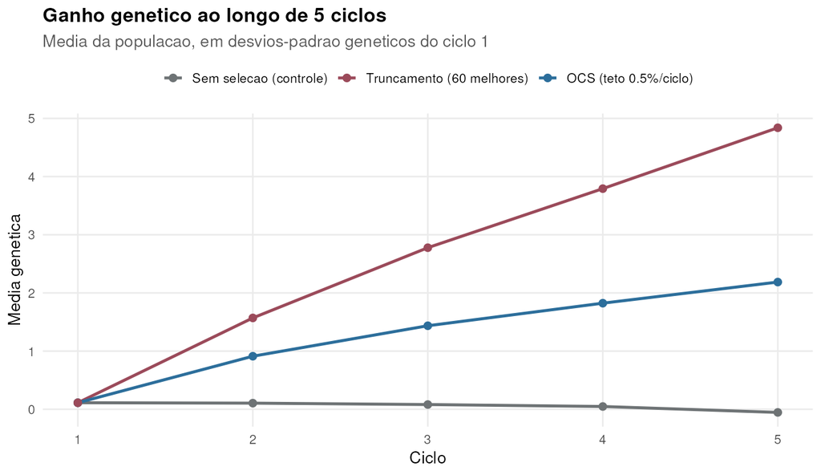

## Diversidade: a conta que chega depois

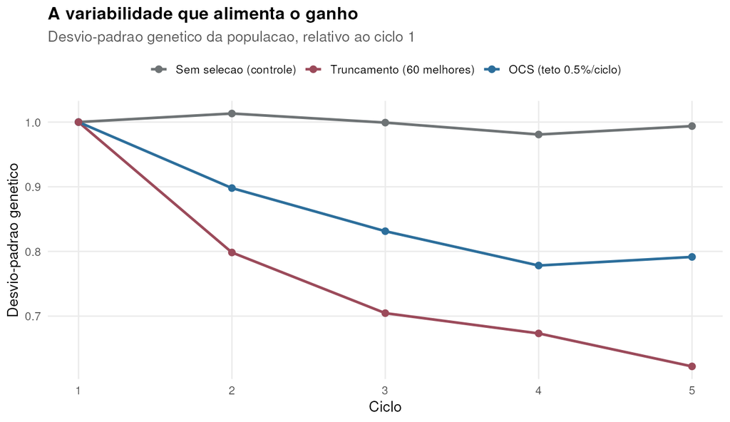

O truncamento ganha mais **e** fecha mais a população. As duas coisas são o mesmo fato visto de dois ângulos.

# 2 · OCS

## O problema, escrito

$$\max_{\mathbf{c}} \; \mathbf{c}'\hat{\mathbf{g}}
\quad \text{s.a.} \quad \mathbf{c}'\mathbf{A}\mathbf{c} \le f, \;\;
\textstyle\sum c_i = 1, \;\; c_i \ge 0$$

| Na fórmula | O que é | Em palavras |
| --- | --- | --- |
| $\mathbf{c}$ | fração dos cruzamentos dada a cada candidato | quanto cada um vai ser **usado** (não “entra ou não entra”) |
| $\mathbf{c}'\hat{\mathbf{g}} = \sum_i c_i \hat{g}_i$ | média dos GEBV, ponderada pelo uso | o **ganho** que eu espero |
| $\mathbf{c}'\mathbf{A}\mathbf{c} = \sum_i \sum_j c_i c_j a_{ij}$ | parentesco médio entre os pais escolhidos | o quanto eles são **aparentados** |
| $f$ | o teto de parentesco | o **limite** que eu aceito |
| $\sum c_i = 1,\; c_i \ge 0$ | as frações somam 100%, nenhuma negativa | é uma **divisão** do total de cruzamentos |

Exemplo com 3 candidatos e $\mathbf{c} = (0{,}5;\ 0{,}3;\ 0{,}2)$: o ganho esperado é $0{,}5\,\hat{g}_1 + 0{,}3\,\hat{g}_2 + 0{,}2\,\hat{g}_3$.

**Importante**

Sem a restrição a solução é trivial e ruim: todo o peso no melhor indivíduo. **A restrição é o que transforma seleção em otimização.**

## Mais endogamia sempre rende mais ganho

Essa é a parte que precisa ficar clara: **pressionar funciona**. Autorizar mais endogamia por ciclo entrega mais ganho — no horizonte que você está olhando.

Então a pergunta nunca é *“quanto ganho eu quero”*.

É **quanto eu posso gastar sem descapitalizar o programa**.

## O teto, e o que ele custa

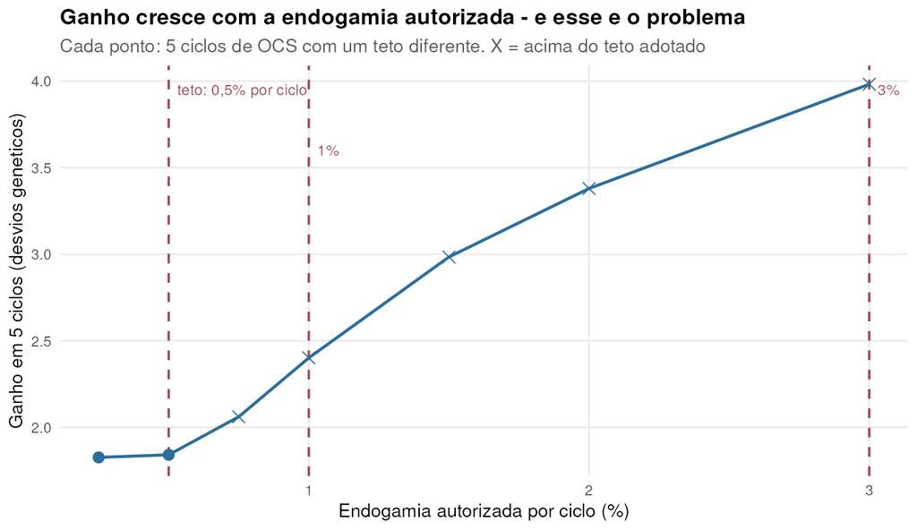

A linha tracejada é o teto de 0,5% por ciclo. À direita dela há mais ganho, pago com mais diversidade gasta. Onde fica o ponto sustentável é a pergunta em aberto.

## Antes de otimizar: a restrição é possível?

Com um pool de candidatos existe um **piso**: o menor parentesco médio alcançável. Pedir abaixo do piso é pedir o impossível.

```r
pc <- piso_coancestria(G[cand, cand])   # gradiente projetado no simplex
oc <- ocs_ga(gebv[cand], G[cand, cand],
             max_coancestria = max(f_alvo, pc$piso * 1.01))
```

**Aviso**

**Pool estreito é uma armadilha silenciosa.** Se o piso ficar acima do teto que você pediu, quem manda é o piso — e tetos diferentes devolvem o **mesmo** resultado. O otimizador não reclama.

# 3 · Alocação

## O orçamento de um programa é medido em parcelas

Com 600 linhagens avaliadas e 3.600 parcelas por ciclo:

$$n_{gen} \times L \times R \;\le\; \text{orçamento}
\qquad\Rightarrow\qquad L \times R \le 6$$

O número de linhagens é **fixo** aqui. Logo a intensidade de seleção é a mesma em todas as opções, e sai da comparação: o que varia é só a **qualidade da medição**.

## Local e repetição não são a mesma coisa

$$h^2_{\bar{y}} = \frac{\sigma^2_g}
{\sigma^2_g + \dfrac{\sigma^2_{ge}}{L} + \dfrac{\sigma^2_e}{L \cdot R}}$$

Olhe onde cada termo aparece:

- **Repetição** divide **só** o erro residual
- **Local** divide o erro residual **e** a interação genótipo × ambiente

**Importante**

Para o **mesmo produto** $L \times R$ — isto é, pelo mesmo preço — mais locais sempre entrega $h^2$ maior. Não é resultado de simulação: está na álgebra.

## A mesma conta, desenhada

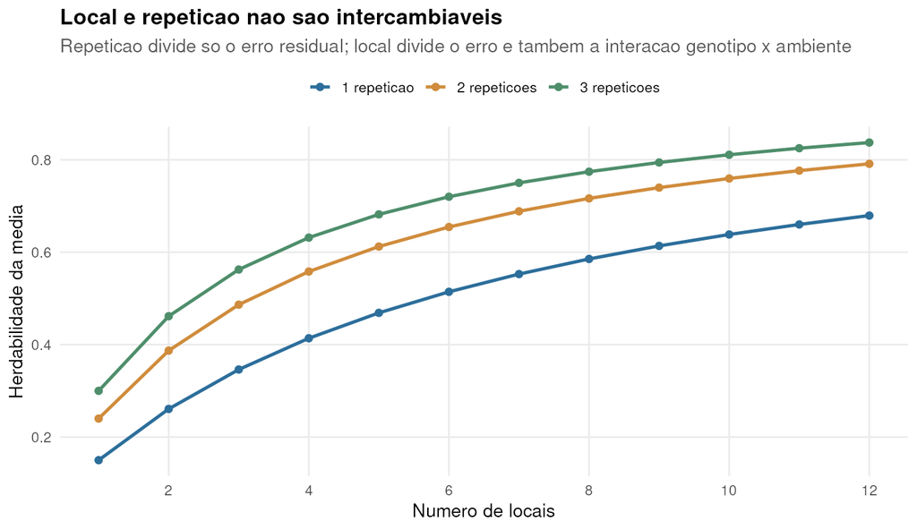

## Quando a repetição paga

- Quando **não há** GxE relevante ($\sigma^2_{ge} \approx 0$): aí local e repetição são intercambiáveis e a conta empata
- Quando o custo de abrir um local novo não é uma parcela, e sim um contrato, uma viagem, uma equipe
- Quando o local novo é **pior** — um ambiente que não representa o alvo não divide o GxE, ele adiciona ruído

**Nota**

A álgebra assume que todo local é igualmente informativo. Essa é a hipótese que você tem de checar no seu programa antes de aplicar a conclusão.

## O que fica

1. **Escreva o objetivo e a restrição.** Sem restrição explícita não existe otimização, existe intuição.
2. **Mais pressão rende mais ganho.** A decisão é quanto você pode gastar, não quanto você quer.
3. **Mais locais, menos repetições** — enquanto houver GxE e todo local for informativo.
4. **Medir melhor não é o objetivo.** Ganhar é.

## Onde a IA entra

- **Escreve a simulação** que você não teria tempo de escrever
- **Não sabe o seu programa**: não conhece seu orçamento, seu GxE, seu teto de endogamia, nem que local novo custa mais que parcela nova
- Por isso ela acerta a **forma** e erra a **premissa** — e premissa errada produz recomendação confiante na direção oposta

**Importante**

O que ela não tem é o que você sabe. É isso que o desafio vai cobrar.

# Desafio · onde gastar as parcelas

## Você dirige o programa

Espécie autógama, um caráter quantitativo, seleção recorrente. **600 linhagens** por ciclo (fixo) e **3.600 parcelas** por ciclo.

$$600 \times L \times R \;\le\; 3.600$$

Vocês escolhem **três números**:

| `L` | quantos locais |
| --- | --- |
| `R` | quantas repetições por local |
| `delta_f` | quanta endogamia por ciclo o OCS pode acumular |

## O que vocês sabem do programa

- Herdabilidade na parcela individual: **0,25**
- Fração da variância genética que é genótipo × ambiente: **40%**
- Horizonte: **5 ciclos**
- Endogamia autorizada por ciclo: **no máximo 1%**

**Aviso**

**No desafio o teto é 1% por ciclo** — não os 0,5% da aula. `delta_f` acima de 1% é escolha inválida.

## Como a escolha é avaliada

**Ganho genético da média da população no ciclo 5**, em desvios-padrão genéticos do ciclo 1.

**O que entregar:** os três números (`L`, `R`, `delta_f`) e **uma frase** dizendo por quê.

20 minutos, em duplas. Arquivos: `DESAFIO_09.docx` e `desafio_09_aluno.R`.

### Obrigado

Perguntas?